# How to compare conStruct model runs

Gideon Bradburd

January 08, 2024

## Model comparison

This document describes how to do model comparison for conStruct analyses. It assumes that you are already familiar with the companion vignette for running conStruct.

**Caveat user!** Although it may sometimes be necessary to simplify the presentation of the results of several analyses by only showing the output from a single “best” run, it is important to remember several things:

1. First, choice of best *K* is always relative to the data at hand, and, as the amount of data increases, statistical support for larger *K* will likely increase. With infinite data, the “best” value of *K* would probably be the number of samples in the dataset.
2. Although we think that conStruct is less likely to falsely ascribe continuous patterns of genetic variation to discrete population clusters than other existing methods, that does not mean that the discrete groups identified by conStruct are biologically real. See “A tutorial on how not to over-interpret STRUCTURE and ADMIXTURE bar plots” (Lawson, van Dorp, and Falush 2018) for a more in-depth discussion of these issues.
3. Finally, as with all other statistical inference, output should be interpreted with care and a large grain of salt. We strongly recommend that users check whether individual runs seem to have performed well and whether results are consistent across independent runs. We also recommend that users compare output across runs with different values of *K* to see which samples split out into their own layers in the different analyses.

So, you’ve run two or more conStruct analyses and you want to compare them to see which might be the best model to describe the variation in your data. There are two methods in the conStruct package for doing model comparison:

1. Cross-validation
2. Calculating layer contributions

Below, I describe both options and give examples for how to use their associated functions in the `conStruct` package and visualize the output they generate.

Note that if you are interested in visually comparing two independent `conStruct` runs, you can use the function `compare.two.runs`, the documentation for which can be found with the  
command `help(compare.two.runs)`. This function is further described in the companion vignette for visualizing results.

## Cross-validation

Cross-validation is a tool for testing how the results of an analysis will generalize to an independent dataset.

### How it works

In general, the more parameters included in the model, the better the fit to the data. To determine an appropriate level of parameterization for a given dataset, we can use cross-validation. In `conStruct`, this works by fitting a model to a “training” subset of the data, then testing the fit to the remaining “testing” subset. If the parameter values estimated from the training data parameterize a model that describes the testing data well, the predictive accuracy of the model is good. If the model is overparameterized, it will fit the training data very well, but may not fit the testing better any better than (or even as well as) a less parameter-rich model. By fitting a given model to many training partitions and testing its fit to the accompanying testing partitions, we can get a mean predictive accuracy for each model. We can then compare predictive accuracies across models to determine which model strikes has the best goodness-of-fit without overfitting.

### How to run a cross-validation analysis

To run a cross-validation analysis in `conStruct`, you can use the `x.validation` function.

```r
# load the library
library(conStruct)

# load the example dataset
data(conStruct.data)

# to run a cross-validation analysis
# you have to specify:
#       the numbers of layers you want to compare (K)
#       the allele frequency data (freqs)
#       the geographic distance matrix (geoDist)
#       the sampling coordinates (coords)

my.xvals <- x.validation(train.prop = 0.9,
                         n.reps = 8,
                         K = 1:3,
                         freqs = conStruct.data$allele.frequencies,
                         data.partitions = NULL,
                         geoDist = conStruct.data$geoDist,
                         coords = conStruct.data$coords,
                         prefix = "example",
                         n.iter = 1e3,
                         make.figs = TRUE,
                         save.files = FALSE,
                         parallel = FALSE,
                         n.nodes = NULL)
```

The `x.validation` function returns a list containing the results of the cross-validation analysis, standardized within each replicate. The model with the best predictive accuracy within each replicate has a standardized score of 0. Smaller (i.e., more negative) values indicate worse model fit to the testing data in that replicate.

For convenience, the function also writes a table of results to a text file for both the spatial model (`prefix_sp_xval_results.txt`) and the nonspatial model (`prefix_nsp_xval_results.txt`). Each column in the table gives the results for a single cross-validation replicate over evaluated values of *K*, and each row gives the results of a given value of *K* across replicates.

The arguments `parallel` and `n.nodes` can be used to parallelize the cross-validation analysis. These are described in further detail below in Parallelization. The argument `data.partitions` allows the user to specify their own training/testing data partitions to be used across replicates. This option is described further below in Specifying data partitions.

### Visualizing results

To visualize the output of a cross-validation analysis, you can use either the output list or the text files. Examples of both are given below.

```r
# read in results from text files

sp.results <- as.matrix(
                read.table("example_sp_xval_results.txt",
                           header = TRUE,
                           stringsAsFactors = FALSE)
               )
nsp.results <- as.matrix(
                read.table("example_nsp_xval_results.txt",
                           header = TRUE,
                           stringsAsFactors = FALSE)
               )

# or, format results from the output list
sp.results <- Reduce("cbind",lapply(my.xvals,function(x){unlist(x$sp)}),init=NULL)
nsp.results <- Reduce("cbind",lapply(my.xvals,function(x){unlist(x$nsp)}),init=NULL)
```

The results look like this:

Spatial cross-validation results

|  | rep1 | rep2 | rep3 | rep4 | rep5 | rep6 | rep7 | rep8 |
| --- | --- | --- | --- | --- | --- | --- | --- | --- |
| K=1 | -1.201 | -4.579 | 0.000 | -7.315 | 0.000 | 0.000 | -3.650 | 0.000 |
| K=2 | 0.000 | -5.730 | -5.346 | -8.853 | -6.125 | -11.155 | 0.000 | -4.799 |
| K=3 | -1.819 | 0.000 | -1.114 | 0.000 | -3.602 | -5.506 | -2.909 | -9.890 |

A quick and dirty plot of the output is given below:

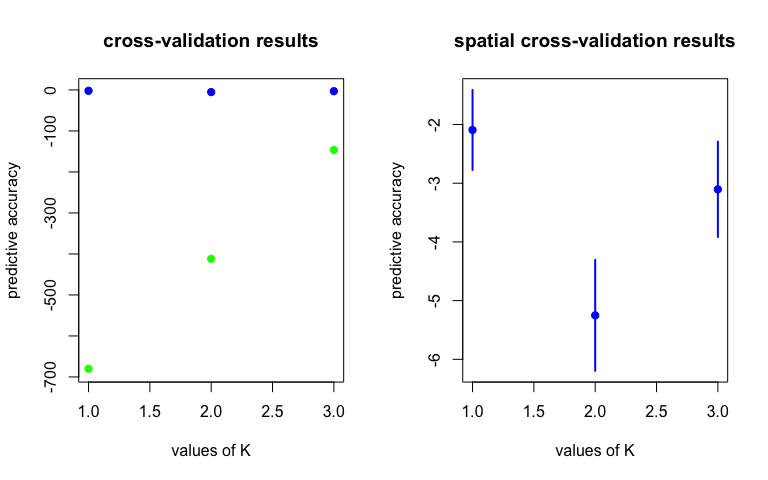

```r
# first, get the 95% confidence intervals for the spatial and nonspatial
#   models over values of K (mean +/- 1.96 the standard error)

sp.CIs <- apply(sp.results,1,function(x){mean(x) + c(-1.96,1.96) * sd(x)/length(x)})
nsp.CIs <- apply(nsp.results,1,function(x){mean(x) + c(-1.96,1.96) * sd(x)/length(x)})

# then, plot cross-validation results for K=1:3 with 8 replicates

par(mfrow=c(1,2))
plot(rowMeans(sp.results),
     pch=19,col="blue",
     ylab="predictive accuracy",xlab="values of K",
     ylim=range(sp.results,nsp.results),
     main="cross-validation results")
    points(rowMeans(nsp.results),col="green",pch=19)

# finally, visualize results for the spatial model
#   separately with its confidence interval bars
#
# note that you could do the same with the spatial model,
#   but the confidence intervals don't really show up
#   because the differences between predictive accuracies
#   across values of K are so large.

plot(rowMeans(sp.results),
     pch=19,col="blue",
     ylab="predictive accuracy",xlab="values of K",
     ylim=range(sp.CIs),
     main="spatial cross-validation results")
segments(x0 = 1:nrow(sp.results),
         y0 = sp.CIs[1,],
         x1 = 1:nrow(sp.results),
         y1 = sp.CIs[2,],
         col = "blue",lwd=2)
```

### Interpreting results

The model with the highest mean predictive accuracy is the “best” model, but, as noted above, we caution against overinterpretation of these cross-validation results. If a significance test for the “best” number of layers is required, you can use a t-test comparing cross-validation scores across values of K, paired by replicate. E.g., `t.test(sp.results[2,],sp.results[1,],paired=TRUE,alternative="greater")`.

I would interpret the results above as strong evidence that the spatial model is preferred over the nonspatial model over all tested values of *K* (indicating that isolation by distance is probably a feature of the data). The cross-validation analyses also strongly support the conclusion that a single spatial layer (*K* = 1) is sufficient to describe the variation in the data.

A final caveat of this section is that, with sufficient data, it is possible to get strong statistical support for layers that contribute little to overall patterns of covariance. Therefore, it’s good to interpret cross-validation results alongside calculated layer contributions (discussed further in Layer Contributions.

### Parallelization

```r
# load the example dataset
data(conStruct.data)

# to run a cross-validation analysis
# you have to specify:
#       the numbers of layers you want to compare (K)
#       the allele frequency data (freqs)
#       the geographic distance matrix (geoDist)
#       the sampling coordinates (coords)

# in addition, here we run our analysis parallelized
#   across all replicates using 4 nodes

my.xvals <- x.validation(train.prop = 0.9,
                         n.reps = 8,
                         K = 1:3,
                         freqs = conStruct.data$allele.frequencies,
                         data.partitions = NULL,
                         geoDist = conStruct.data$geoDist,
                         coords = conStruct.data$coords,
                         prefix = "example",
                         n.iter = 1e3,
                         make.figs = TRUE,
                         save.files = FALSE,
                         parallel = TRUE,
                         n.nodes = 4)
```

The example above should run ~4 times as fast as cross-validation with the same number of replicates not run in parallel. At the end of the cross-validation analysis, the parallel workers generated at the beginning of the run will be terminated.

To facilitate greater flexibility in parallelization, users can also specify their own parallelization scheme before running a cross-validation analysis, in which case they should simply set `parallel=TRUE` and make sure that `n.nodes` is equal to the number of nodes they’ve set up. If you’ve set up your own parallelization beforehand (as in the example that follows), `x.validation` will use that set-up rather than initializing one itself. E.g.,

```r
library(parallel)
library(foreach)
library(doParallel)

cl <- makeCluster(4,type="FORK")
registerDoParallel(cl)

my.xvals <- x.validation(train.prop = 0.9,
                         n.reps = 8,
                         K = 1:3,
                         freqs = conStruct.data$allele.frequencies,
                         data.partitions = NULL,
                         geoDist = conStruct.data$geoDist,
                         coords = conStruct.data$coords,
                         prefix = "example",
                         n.iter = 1e3,
                         make.figs = TRUE,
                         save.files = FALSE,
                         parallel = TRUE,
                         n.nodes = 4)

stopCluster(cl)
```

Note that if you have prespecified a parallelization scheme, you are responsible for ending the parallelization yourself, as shown above with the `stopCluster()` call. Linux and Mac users may wish use `makeCluster(N,type="FORK")`, as it does better with memory usage. Windows users should user the default PSOCK cluster (e.g., `makeCluster(N,type="PSOCK")`).

## Layer contributions

Layer contributions offer a second metric users can employ to compare models with different numbers of layers.

### How it works

In a `conStruct` run, users are estimating a parametric covariance matrix to fit their sample allelic covariance. Each layer in the model contributes to that parametric covariance, and those contributions can be calculated and compared. If there is a layer that no samples draw appreciable admixture from, it will contribute almost nothing to overall covariance, and is therefore of little biological importance in the model.

By comparing layer contributions across different `conStruct` analyses run with different values of *K*, users can identify the point at which layers included in the analysis contribute little to overall covariance, and pick a “best” value of *K* below that point.

### How to calculate layer contributions

Layer contributions are calculated from the output of a standard `conStruct` analysis using the function `calculate.layer.contribution`.

```r
# Loop through output files generated by conStruct
#   runs with K=1 through 5 and calculate the
#   layer contributions for each layer in each run

layer.contributions <- matrix(NA,nrow=5,ncol=5)

# load the conStruct.results.Robj and data.block.Robj
#   files saved at the end of a conStruct run
load("K1_sp_conStruct.results.Robj")
load("K1_sp_data.block.Robj")

# calculate layer contributions
layer.contributions[,1] <- c(calculate.layer.contribution(conStruct.results[[1]],data.block),rep(0,4))
tmp <- conStruct.results[[1]]$MAP$admix.proportions

for(i in 2:5){
    # load the conStruct.results.Robj and data.block.Robj
    #   files saved at the end of a conStruct run
    load(sprintf("K%s_sp_conStruct.results.Robj",i))
    load(sprintf("K%s_sp_data.block.Robj",i))

    # match layers up across runs to keep plotting colors consistent
    #   for the same layers in different runs
    tmp.order <- match.layers.x.runs(tmp,conStruct.results[[1]]$MAP$admix.proportions)

    # calculate layer contributions
    layer.contributions[,i] <- c(calculate.layer.contribution(conStruct.results=conStruct.results[[1]],
                                                             data.block=data.block,
                                                             layer.order=tmp.order),
                                    rep(0,5-i))
    tmp <- conStruct.results[[1]]$MAP$admix.proportions[,tmp.order]
}
```

Note that, because layers can label switch across runs, the example above uses the `match.layers.x.runs` function to determine which layers correspond to each other across analyses run with different values of *K*.

### Visualizing results

The table of layer contributions looks like this:

Contributions for each layer for runs done with K=1 through 5

|  | K=1 | K=2 | K=3 | K=4 | K=5 |
| --- | --- | --- | --- | --- | --- |
| Layer_1 | 1 | 0.68 | 0.682 | 0.678 | 0.684 |
| Layer_2 | 0 | 0.32 | 0.318 | 0.322 | 0.315 |
| Layer_3 | 0 | 0.00 | 0.000 | 0.000 | 0.000 |
| Layer_4 | 0 | 0.00 | 0.000 | 0.000 | 0.000 |
| Layer_5 | 0 | 0.00 | 0.000 | 0.000 | 0.000 |

Layer contributions can be easily plotted across values of *K* using a stacked barplot:

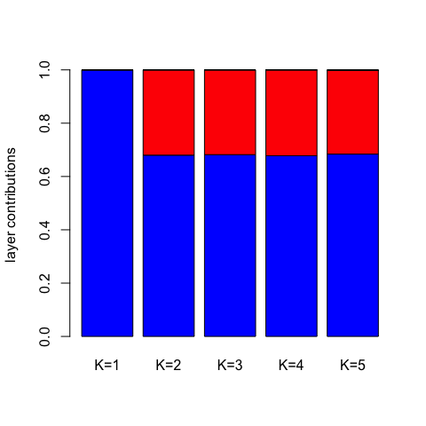

```r
barplot(layer.contributions,
        col=c("blue", "red", "goldenrod1", "forestgreen", "darkorchid1"),
        xlab="",
        ylab="layer contributions",
        names.arg=paste0("K=",1:5))
```

In this case, the contributions of layers beyond *K* = 2 is so small that they don’t even show up on the barplot.

### Interpreting results

If a layer in a given model contributes very little to overall covariance, it is unlikely to have much biological significance. If you run `conStruct` analyses across values of *K*, and see that, after a certain value of *K*, no additional clusters contribute much to overall covariance, that may be a good indication that that value of *K* (or at least, no larger value of *K*) is best for describing the variation in your data. For example, in the layer contributions plotted above in Visualizing results, additional layers after *K* = 2 have negligible layer contributions, so we might reasonably conclude that the best value of *K* for describing our data is no greater than 2.

Users can also set some threshold (e.g., 0.01) below which they count a layer’s contribution as negligible, and, by setting this threshold *a priori*, can use layer contributions as a metric for model selection.

## Cross-validation vs. Layer contribution

With sufficient data, a cross-validation analysis may indicate strong support for layers that each contribute very little to overall covariance. In such a case, the input from cross-validation and layer contributions are at odds, with the former arguing for the inclusion of more layers, and the latter arguing against. What to do with that situation?

Well, the specifics will vary from dataset to dataset, but we encourage users to distinguish between statistical and biological significance, and not get too caught up in the first at the expense of the second.